# Un análisis real con CausalMultiOmics

Cohorte de prevención cardiovascular: de tres bloques de datos a una afirmación que podría ser falsa

Generado el 16 de septiembre de 2026

Este documento recorre el paquete entero como lo haría alguien que tiene tres bloques ómicos y una pregunta clínica. No es la *vignette* —esa explica por qué el paquete está diseñado así— sino el cuaderno de un análisis: cada función pública, cada modo de analizar, las figuras que se producen y qué hay dentro de los objetos que devuelve.

> **Requiere CausalMultiOmics ≥ 0.1.1 instalado.** El documento usa `cmo_setup()`, `plot()`, `as.data.frame()` y `outcome_name()`, que se añadieron en esa versión. Si acabas de actualizar el código fuente, instálalo (`devtools::install()`, o `Ctrl+Shift+B` en RStudio) y reinicia R antes de ejecutarlo: `library()` carga la copia **instalada**, no el repositorio.

Los datos son simulados **con una estructura causal conocida**, que declaro ahora para poder juzgar al final si el paquete la recuperó:

```
edad ─→ Met_TMAO ─→ Prot_IL6 ─→ evento
  │        ↑                      ↑
  └────────┴── imc                └── edad, ldl (efectos directos)
```

Es decir: la señal real está en un metabolito y una proteína, con la edad y el IMC como confusores que entran por dos caminos a la vez. El resto —24 metabolitos y 17 proteínas— es ruido puro. Un análisis honesto debería encontrar la vía y no encontrar el ruido.

# 1 Antes de empezar: qué puede ejecutar esta máquina

```r
cmo_setup()
```

| component | label | status | requires | missing | kind |
| --- | --- | --- | --- | --- | --- |
| association | Adjusted association | available |  |  | generator |
| conditional | Conditional independence | available |  |  | generator |
| survival | Cox proportional hazards | available | survival |  | generator |
| longitudinal | Linear mixed model | available | lme4 |  | generator |
| mediation | Bootstrap mediation | available |  |  | generator |
| elasticnet | Elastic net selection | available | glmnet |  | generator |
| randomforest | Random forest importance | available | ranger |  | generator |
| bayesnet | Bayesian network structure | unavailable | bnlearn | bnlearn | generator |
| sem | Structural equation model | available | lavaan |  | generator |
| imputation:knn | imputation method | unavailable | VIM | VIM | preprocessing |
| imputation:mice | imputation method | unavailable | mice | mice | preprocessing |
| imputation:missForest | imputation method | unavailable | missForest | missForest | preprocessing |
| batch:combat | batch method | unavailable | sva | sva | preprocessing |
| batch:harmony | batch method | unavailable | harmony | harmony | preprocessing |
| batch:ruv | batch method | unavailable | RUVSeq | RUVSeq | preprocessing |
| feature_selection:boruta | feature_selection method | unavailable | Boruta | Boruta | preprocessing |
| feature_selection:lasso | feature_selection method | available | glmnet |  | preprocessing |
| feature_selection:relief | feature_selection method | unavailable | FSelectorRcpp | FSelectorRcpp | preprocessing |

Esto importa más de lo que parece: la puntuación de evidencia **pondera el acuerdo entre métodos**, así que una relación vista por un generador puntúa por debajo de la misma relación vista por cuatro. Un motor incompleto no da una respuesta más pequeña: da una respuesta sesgada a la baja.

# 2 Los datos

Tres bloques y una tabla de metadatos, como salen de tres plataformas distintas. Los identificadores van en `row.names` de cada bloque y en la columna `sample_id` de los metadatos.

```r
set.seed(2024)
n  <- 400
id <- sprintf("CV%04d", seq_len(n))

# --- confusores clínicos ----------------------------------------------------
edad <- round(rnorm(n, 64, 9))
sexo <- rbinom(n, 1, 0.46)
imc  <- rnorm(n, 28, 4) + 0.02 * (edad - 64)
tas  <- rnorm(n, 136, 16) + 0.35 * (edad - 64) + 0.6 * (imc - 28)
ldl  <- rnorm(n, 112, 28) + 0.25 * (edad - 64)

# --- la vía plantada: edad -> Met_TMAO -> Prot_IL6 -> evento ----------------
met_tmao <- 0.55 * scale(edad)[, 1] + 0.30 * scale(imc)[, 1] + rnorm(n, 0, 0.75)
prot_il6 <- 0.60 * met_tmao + 0.25 * scale(imc)[, 1] + rnorm(n, 0, 0.75)

# --- desenlaces -------------------------------------------------------------
lp     <- -1.1 + 0.85 * prot_il6 + 0.45 * met_tmao +
           0.030 * (edad - 64) + 0.011 * (ldl - 112)
evento <- rbinom(n, 1, plogis(lp))
tiempo <- pmin(round(rexp(n, 0.02 * exp(0.45 * prot_il6)) + 1), 60)
hdl    <- 52 - 3.2 * prot_il6 - 0.08 * (imc - 28) + rnorm(n, 0, 7)

# --- los tres bloques -------------------------------------------------------
clinica <- data.frame(edad = edad, sexo = sexo, imc = round(imc, 1),
                      tas = round(tas), ldl = round(ldl), row.names = id)

metabolomica <- as.data.frame(
  cbind(Met_TMAO = met_tmao,
        matrix(rnorm(n * 24), n, 24,
               dimnames = list(NULL, sprintf("Met_%02d", 1:24)))),
  row.names = id)

# tres columnas con los defectos que trae cualquier panel real: una variable
# por debajo del limite de deteccion, otra casi constante, y una duplicada de
# la anterior por un problema de exportacion
metabolomica$Met_LOD   <- 0
metabolomica$Met_NEARC <- c(rep(1, n - 4), rnorm(4, 1, 0.01))
metabolomica$Met_DUP   <- metabolomica$Met_01 + rnorm(n, 0, 1e-6)

proteomica <- as.data.frame(
  cbind(Prot_IL6 = prot_il6,
        matrix(rnorm(n * 17), n, 17,
               dimnames = list(NULL, sprintf("Prot_%02d", 1:17)))),
  row.names = id)
proteomica$Prot_04[sample(n, 40)] <- NA      # perdidos como en un panel real

metadatos <- data.frame(sample_id = id, evento = evento, tiempo = tiempo,
                        hdl = round(hdl, 1), stringsAsFactors = FALSE)
```

`load_data()` alinea los bloques por identificador y se queja si no puede:

```r
datos <- load_data(
  assays = list(clinica = clinica, metabolomica = metabolomica,
                proteomica = proteomica),
  metadata = metadatos
)

datos
```

```
#>
#> MultiOmicsData
#> ==============
#>
#> Blocks:                3
#> Samples:               400
#> Features:              51
#> Metadata:              Yes
#> Preprocessing:         0
#> History:               1
```

`summary()` da el desglose por bloque. A partir de la versión 0.1.1 **devuelve** el resumen en lugar de imprimirlo, así que se puede guardar en una variable y recorrerlo; lo que se ve en la consola es idéntico porque es `print()` quien lo escribe.

```r
summary(datos)
```

```
#>
#> ========== MultiOmicsData Summary ==========
#>
#> Blocks
#> ------
#> clinica                   400 samples x        5 features
#> metabolomica              400 samples x       28 features
#> proteomica                400 samples x       18 features
#>
#> Metadata
#> --------
#> 400 rows
#>
#> Preprocessing
#> -------------
#> None
#>
#> History
#> -------
#> - load_data(): 3 block(s), 400 sample(s), 51 feature(s) [2026-09-16 21:51:13]
```

## 2.1 Lo que pasa si los identificadores no encajan

Vale la pena ver los mensajes de error antes de necesitarlos. El paquete separa dos papeles: `load_data()` **importa** y `check_data()` **audita**. Por eso lo primero solo rechaza lo que no puede ni construir:

```r
# un bloque sin identificadores en row.names
load_data(assays = list(a = data.frame(x = rnorm(10))))
```

```
#> Error in `load_data()`:
#> ! Block 'a' has no sample identifiers. Set them before calling load_data(), e.g. rownames(x) <- ids.
#>   Without them every block is labelled '1', '2', ..., which makes unrelated blocks appear to share all their samples and silently breaks matching against metadata.
```

```r
# metadatos con los identificadores en row.names en vez de en sample_id:
# es la misma convención que usan los bloques, así que se aceptan con aviso
meta_rn <- data.frame(evento = evento, row.names = id)
aud_rn  <- check_data(load_data(list(clinica = clinica), metadata = meta_rn),
                      plots = FALSE)
aud_rn$warnings
```

```
#> [1] "Metadata has no 'sample_id' column; its row names were used as identifiers. Add metadata$sample_id <- rownames(metadata) to make this explicit."
```

```r
# metadatos que no comparten NINGÚN identificador: no es cobertura parcial,
# son etiquetas equivocadas, y eso sí es un error de validación
meta_mal <- data.frame(sample_id = sprintf("X%04d", 1:n), evento = evento,
                       stringsAsFactors = FALSE)
aud_mal  <- check_data(load_data(list(clinica = clinica), metadata = meta_mal),
                       plots = FALSE)
c(valido = aud_mal$valid, errores = length(aud_mal$errors))
```

```
#>  valido errores
#>       0       1
```

```r
aud_mal$errors
```

```
#> [1] "No identifier in the metadata matches any data block. Metadata: X0001, X0002, X0003. Blocks: CV0001, CV0002, CV0003. Both sides must use the same labels; check for a prefix, a type mismatch (\"1\" vs 1) or trailing whitespace."
```

# 3 Auditoría: mirar antes de tocar

`check_data()` no transforma nada. Mide, y propone una receta de preprocesado por bloque que el usuario puede aceptar o reescribir.

```r
auditoria <- check_data(datos)
auditoria
```

```
#>
#> CMOValidation
#> =============
#>
#> Status:                        VALID
#> Quality score:                 96.09
#> Blocks:                        3
#> Samples:                       400
#> Features:                      51
#> Errors:                        0
#> Warnings:                      1
#> Recipes:                       3
```

El objeto ya trae la tabla que uno quiere leer:

```r
as.data.frame(auditoria)
```

| block | samples | features | missing_percent | constant_features | near_constant_features | empty_samples | empty_features |
| --- | --- | --- | --- | --- | --- | --- | --- |
| clinica | 400 | 5 | 0.00 | 0 | 0 | 0 | 0 |
| metabolomica | 400 | 28 | 0.00 | 1 | 1 | 0 | 0 |
| proteomica | 400 | 18 | 0.56 | 0 | 0 | 0 | 0 |

Y los avisos en texto, que aquí son sobre los perdidos que planté en `Prot_04`:

```r
auditoria$warnings
```

```
#> [1] "proteomica: 0.56% missing values."
```

## 3.1 Las figuras de la auditoría

Las figuras están **dentro** del objeto, grabadas. `cmo_plots()` dice qué hay:

```r
cmo_plots(auditoria)
```

```
#>
#> 21 figure(s) available
#>
#>   missing_heatmap                per block: clinica, metabolomica, proteomica
#>   missing_by_block
#>   missing_by_sample              per block: proteomica
#>   missing_by_feature             per block: proteomica
#>   missing_pattern                per block: clinica, metabolomica, proteomica
#>   overlap_heatmap
#>   overlap_network
#>   correlation_heatmap            per block: clinica, metabolomica, proteomica
#>   correlation_distribution       per block: clinica, metabolomica, proteomica
#>   histograms                     per block: clinica, metabolomica, proteomica
#>   density                        per block: clinica, metabolomica, proteomica
#>   qqplots                        per block: clinica, metabolomica, proteomica
#>   boxplots                       per block: clinica, metabolomica, proteomica
#>   violinplots                    per block: clinica, metabolomica, proteomica
#>   pca                            per block: clinica, metabolomica, proteomica
#>   scree                          per block: clinica, metabolomica, proteomica
#>   sample_clustering              per block: clinica, metabolomica, proteomica
#>   feature_clustering             per block: clinica, metabolomica, proteomica
#>   outliers                       per block: clinica, metabolomica, proteomica
#>   transformation_scores          per block: clinica, metabolomica, proteomica
#>   transformation_comparison      per block: clinica, metabolomica, proteomica
#>
#> Draw one with:  plot(x, "missing_heatmap")
```

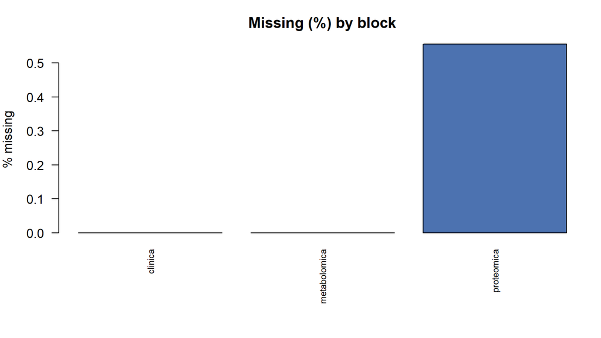

```r
plot(auditoria, "missing_by_block")
```

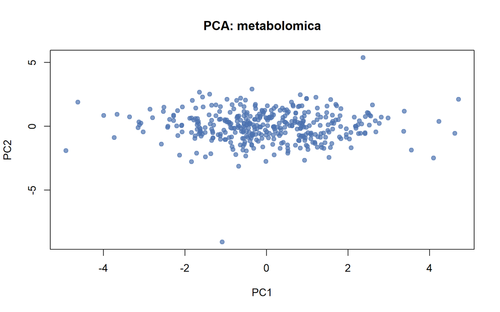

```r
plot(auditoria, "pca", block = "metabolomica")
```

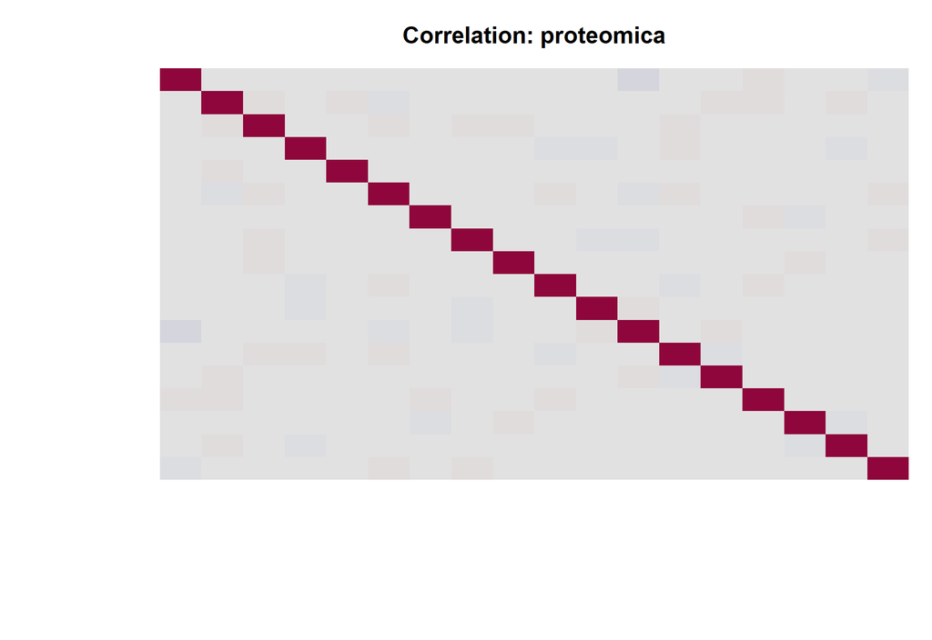

```r
plot(auditoria, "correlation_heatmap", block = "proteomica")
```

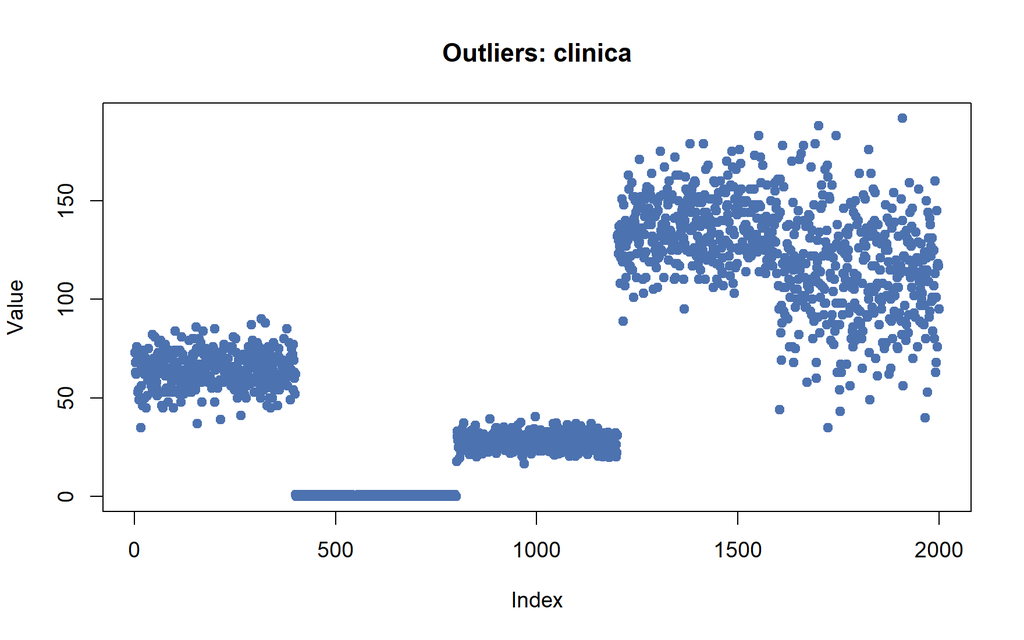

```r
plot(auditoria, "outliers", block = "clinica")
```

La última es la que decide el preprocesado: para cada variable puntúa ocho transformaciones candidatas y se queda con la mejor.

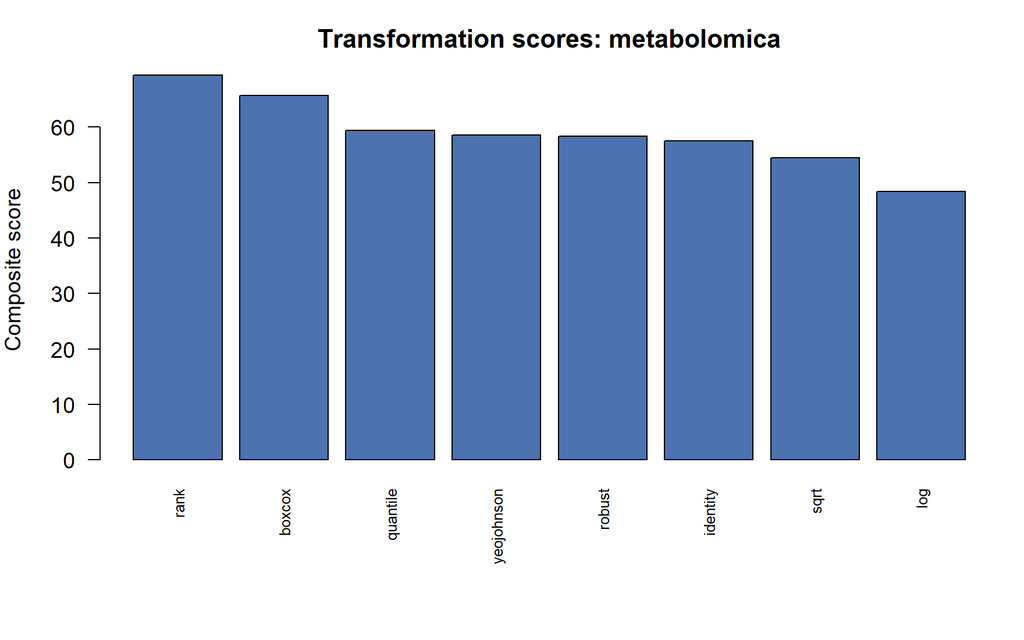

```r
plot(auditoria, "transformation_scores", block = "metabolomica")
```

## 3.2 Una nota de rendimiento

Las figuras son el 4-6 % del tiempo de `check_data()` pero cerca del 90 % del tamaño del objeto. Con paneles grandes —o si vas a guardar la auditoría junto a la cohorte— conviene omitirlas:

```r
sin_figuras <- check_data(datos, plots = FALSE)

data.frame(
  version = c("check_data(datos)", "check_data(datos, plots = FALSE)"),
  MB = round(c(as.numeric(object.size(auditoria)),
               as.numeric(object.size(sin_figuras))) / 1024^2, 1),
  hallazgos_identicos = c(TRUE, identical(as.data.frame(sin_figuras),
                                          as.data.frame(auditoria)))
)
```

| version | MB | hallazgos_identicos |
| --- | --- | --- |
| check_data(datos) | 8.0 | TRUE |
| check_data(datos, plots = FALSE) | 0.5 | TRUE |

El tiempo de `check_data()` crece de forma **lineal** con el número de variables, a razón de unos 43 ms por variable con n = 300; un panel de 5 000 variables son minutos, no horas, pero conviene saberlo antes de lanzarlo.

# 4 Preprocesado: ejecutar el plan y nada más

```r
listo <- preprocess(datos, auditoria)
```

```
#> Preprocessing 'clinica'...
#> Preprocessing 'metabolomica'...
#> Preprocessing 'proteomica'...
```

```
#> Done: 16 step(s) in 1.73 s
```

```r
listo
```

```
#>
#> PreprocessingResult
#> ===================
#>
#> Blocks:                        3
#> Recipes:                       3
#> Steps executed:                16
#> Removed samples:               0
#> Removed features:              2
#> Plots:                         7
#> Runtime:                       1.73 s
```

La receta que se aplicó, bloque por bloque:

```r
summary(listo$recipes$metabolomica)
```

```
#>
#> ========== Preprocessing Recipe ==========
#>
#> General
#> -------
#> Block                          metabolomica
#> Objective                      Prepare 'metabolomica' (continuous data) for downstream integration.
#> Automatic                      Yes
#>
#> Filtering
#> ---------
#> Remove empty samples           FALSE
#> Remove empty features          FALSE
#> Remove constant features       TRUE
#> Remove near constant           TRUE
#> Remove duplicate samples       FALSE
#> Remove duplicate features      FALSE
#>
#> Missing values
#> --------------
#> Method                         none
#>
#> Transformation
#> ----------------
#> Method                         rank
#> Score                          69.34
#>
#> Reason
#> ------
#> - Highest composite score (69.3/100) among 8 candidate transformation(s).
#> - Low outlier rate after transformation (0.0%).
#>
#> Normalization
#> -------------
#> Method                         none
#>
#> Scaling
#> -------
#> Method                         z-score
#>
#> Batch correction
#> ----------------
#>
#> Feature selection
#> -----------------
#>
#> Expected quality
#> ----------------
#> Estimated quality              93.9946428571428
```

Y la trazabilidad completa: cada paso, con las dimensiones antes y después. Esta tabla es la razón de existir del paquete —nada desaparece sin quedar registrado— y hasta la versión 0.1.1 el contador de variables eliminadas no la respetaba.

```r
as.data.frame(listo)
```

| step | block | stage | method | samples | features | removed_samples | removed_features | runtime | replay |
| --- | --- | --- | --- | --- | --- | --- | --- | --- | --- |
| 1 | clinica | remove_samples | structural_filter | 400 -> 400 | 5 -> 5 | 0 | 0 | 0.0006 | FALSE |
| 2 | clinica | remove_features | structural_filter | 400 -> 400 | 5 -> 5 | 0 | 0 | 0.0004 | TRUE |
| 3 | clinica | transformation | identity | 400 -> 400 | 5 -> 5 | 0 | 0 | 0.6847 | TRUE |
| 4 | clinica | scaling | z-score | 400 -> 400 | 5 -> 5 | 0 | 0 | 0.0182 | TRUE |
| 5 | clinica | filter | statistical_filter | 400 -> 400 | 5 -> 5 | 0 | 0 | 0.0006 | TRUE |
| 6 | metabolomica | remove_samples | structural_filter | 400 -> 400 | 28 -> 28 | 0 | 0 | 0.0261 | FALSE |
| 7 | metabolomica | remove_features | structural_filter | 400 -> 400 | 28 -> 26 | 0 | 2 | 0.1264 | TRUE |
| 8 | metabolomica | transformation | rank | 400 -> 400 | 26 -> 26 | 0 | 0 | 0.0244 | TRUE |
| 9 | metabolomica | scaling | z-score | 400 -> 400 | 26 -> 26 | 0 | 0 | 0.0050 | TRUE |
| 10 | metabolomica | filter | statistical_filter | 400 -> 400 | 26 -> 26 | 0 | 0 | 0.0396 | TRUE |
| 11 | proteomica | remove_samples | structural_filter | 400 -> 400 | 18 -> 18 | 0 | 0 | 0.0007 | FALSE |
| 12 | proteomica | remove_features | structural_filter | 400 -> 400 | 18 -> 18 | 0 | 0 | 0.0010 | TRUE |
| 13 | proteomica | imputation | median | 400 -> 400 | 18 -> 18 | 0 | 0 | 0.0031 | TRUE |
| 14 | proteomica | transformation | identity | 400 -> 400 | 18 -> 18 | 0 | 0 | 0.0044 | TRUE |
| 15 | proteomica | scaling | z-score | 400 -> 400 | 18 -> 18 | 0 | 0 | 0.0037 | TRUE |
| 16 | proteomica | filter | statistical_filter | 400 -> 400 | 18 -> 18 | 0 | 0 | 0.0010 | TRUE |

```r
data.frame(
  bloque   = names(datos$assays),
  entrada  = sapply(datos$assays, ncol),
  salida   = sapply(listo$data$assays, ncol),
  declaradas = sapply(names(datos$assays),
                      function(b) length(listo$removed_features[[b]])),
  row.names = NULL
)
```

| bloque | entrada | salida | declaradas |
| --- | --- | --- | --- |
| clinica | 5 | 5 | 0 |
| metabolomica | 28 | 26 | 2 |
| proteomica | 18 | 18 | 0 |

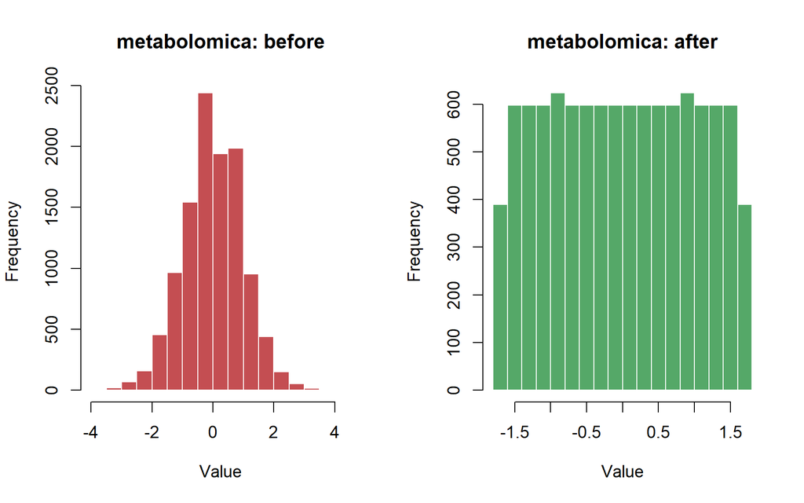

```r
plot(listo, "comparison", block = "metabolomica")
```

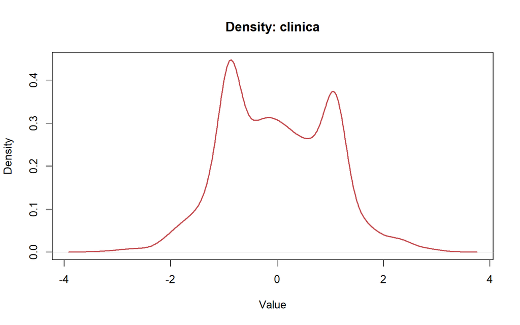

```r
plot(listo, "density", block = "clinica")
```

# 5 Declarar los supuestos antes de estimar

Aquí es donde un paquete causal se separa de una batería de regresiones. Los supuestos no son argumentos sueltos de la función de análisis: son un objeto que se escribe, se lee y viaja con el resultado.

```r
supuestos <- analysis_assumptions(
  # el DAG que creemos: se usa para decidir qué es confusor y qué es mediador
  dag = data.frame(
    from = c("edad", "imc", "Met_TMAO", "Prot_IL6", "edad", "ldl"),
    to   = c("Met_TMAO", "Met_TMAO", "Prot_IL6", "evento", "evento", "evento"),
    stringsAsFactors = FALSE),

  # lo que un clínico podría cambiar: solo sobre esto se calculan contrafactuales
  modifiable = c("clinica", "Met_TMAO"),

  # controles negativos: variables que NO deberían salir. Si salen, el
  # procedimiento está encontrando cosas donde no hay nada
  negative_controls = c("Met_20", "Prot_15"),

  # aristas imposibles por temporalidad: nada causa la edad
  forbidden = data.frame(from = c("evento", "Prot_IL6"),
                         to   = c("edad", "edad"),
                         stringsAsFactors = FALSE),

  # ¿el efecto es el mismo en todos? se explora por estas variables
  heterogeneity = c("sexo", "edad")
)

names(supuestos)
```

```
#>  [1] "dag"               "modifiable"        "negative_controls" "heterogeneity"
#>  [5] "reliability"       "competing"         "forbidden"         "required"
#>  [9] "positivity"        "min_residual"
```

El control es lo otro: no *qué creemos*, sino *cómo se calcula*.

```r
control <- analysis_control(
  methods = c("association", "conditional", "mediation",
              "elasticnet", "randomforest"),
  goal = "causal",           # explicar, no predecir
  bootstrap = 200,
  max_features = 200,        # por encima de esto se criba antes de modelar
  seed = 2024
)
```

# 6 El análisis

```r
resultado <- analyze(
  listo,
  outcome = "evento",
  effort  = "standard",
  assume  = supuestos,
  control = control
)
```

```
#> Aligning blocks...
#>   400 sample(s), 49 feature(s), design: cross-sectional
#> Running Adjusted association...
#> Running Conditional independence...
#> Running Bootstrap mediation...
#> Running Elastic net selection...
#> Running Random forest importance...
#> Integrating evidence...
#>   Quality: 17 relationship(s) involve imputed data.
#>   DAG: 4 identified, 3 with a harmful adjustment.
#>   Concentration: 2 relationship(s) rest on a small minority.
#> Resampling (50 bootstrap replicates, roughly 2.1 min)...
#>     25/50 replicates
#>     50/50 replicates
#>   Consensus: 37/42 reported relationships recur; 5 recur but were not reported.
```

```
#> Done: 42 relationship(s) from 5 method(s) in 37.07 s
```

```r
resultado
```

```
#>
#> CMOResult
#> =========
#>
#> Outcome:                       evento
#> Design:                        cross-sectional
#> Samples:                       400
#> Features analysed:             49 of 49
#>
#> Methods run:                   5 of 5
#> Relationships found:           82
#> After integration:             42
#> With temporal precedence:      0
#>
#> Causal paths:                  3
#> Plots:                         8
#> Tables:                        15
#> Runtime:                       37.07 s
```

La cabecera dice cuánto del motor corrió. Desde 0.1.1 también dice cuántos generadores se saltaron y por qué, distinguiendo los dos motivos: los que faltan por no tener el paquete instalado —evitable— y los que no aplican al diseño detectado —correcto.

```r
resultado$performance$generators_skipped
```

```
#> list()
```

## 6.1 Los hallazgos como tabla

```r
hallazgos <- as.data.frame(resultado)
head(hallazgos, 12)
```

| source | target | direction | estimate | p_value | fdr | n | identification | level | level_label | evidence_score | e_value | n_methods | methods | temporal |
| --- | --- | --- | --- | --- | --- | --- | --- | --- | --- | --- | --- | --- | --- | --- |
| Prot_IL6 | evento | positive | 1.1256276 | 0.0000000 | 0.0000000 | 400 | adjustment | 2 | associational | 21.73 | 5.615 | 3 | logistic regression; elastic net; random forest importance | FALSE |
| Met_TMAO | evento | positive | 0.8978358 | 0.0000000 | 0.0000000 | 400 | none | 2 | associational | 16.43 | 4.344 | 3 | logistic regression; elastic net; random forest importance | FALSE |
| edad | evento | positive | 0.5849454 | 0.0000020 | 0.0000332 | 400 | none | 2 | associational | 14.16 | 2.989 | 2 | logistic regression; random forest importance | FALSE |
| imc | evento | positive | 0.5416739 | 0.0000043 | 0.0000527 | 400 | none | 2 | associational | 13.40 | 2.830 | 2 | logistic regression; random forest importance | FALSE |
| Prot_01 | evento | negative | -0.2041664 | 0.0638332 | 0.4309639 | 400 | none | 2 | associational | 10.05 | 1.754 | 1 | logistic regression | FALSE |
| tas | evento | positive | 0.2001320 | 0.0703615 | 0.4309639 | 400 | none | 2 | associational | 9.86 | 1.742 | 1 | logistic regression | FALSE |
| Met_07 | evento | negative | -0.1675575 | 0.1304077 | 0.5854702 | 400 | none | 2 | associational | 7.57 | 1.647 | 1 | logistic regression | FALSE |
| Prot_10 | evento | positive | 0.1646138 | 0.1362354 | 0.5854702 | 400 | none | 2 | associational | 7.44 | 1.638 | 1 | logistic regression | FALSE |
| Prot_14 | evento | negative | -0.1547750 | 0.1642826 | 0.6192188 | 400 | none | 2 | associational | 6.84 | 1.609 | 1 | logistic regression | FALSE |
| edad | Met_TMAO | positive | 0.0809062 | 0.0000000 | 0.0000000 | 400 | adjustment | 4 | mechanistic | 6.17 | 1.363 | 1 | bootstrap mediation | FALSE |
| Prot_04 | evento | negative | -0.2359134 | 0.0378411 | 0.3673282 | 400 | adjustment | 2 | associational | 5.59 | 1.846 | 2 | logistic regression; random forest importance | FALSE |
| Met_04 | evento | negative | -0.2232392 | 0.0449790 | 0.3673282 | 400 | adjustment | 2 | associational | 5.30 | 1.809 | 2 | logistic regression; random forest importance | FALSE |

Van ordenados por evidencia, así que `head()` es la parte que interesa. Los dos filtros que uno quiere el 90 % de las veces son argumentos:

```r
as.data.frame(resultado, outcome_only = TRUE, min_score = 10)
```

| source | target | direction | estimate | p_value | fdr | n | identification | level | level_label | evidence_score | e_value | n_methods | methods | temporal |
| --- | --- | --- | --- | --- | --- | --- | --- | --- | --- | --- | --- | --- | --- | --- |
| Prot_IL6 | evento | positive | 1.1256276 | 0.0000000 | 0.0000000 | 400 | adjustment | 2 | associational | 21.73 | 5.615 | 3 | logistic regression; elastic net; random forest importance | FALSE |
| Met_TMAO | evento | positive | 0.8978358 | 0.0000000 | 0.0000000 | 400 | none | 2 | associational | 16.43 | 4.344 | 3 | logistic regression; elastic net; random forest importance | FALSE |
| edad | evento | positive | 0.5849454 | 0.0000020 | 0.0000332 | 400 | none | 2 | associational | 14.16 | 2.989 | 2 | logistic regression; random forest importance | FALSE |
| imc | evento | positive | 0.5416739 | 0.0000043 | 0.0000527 | 400 | none | 2 | associational | 13.40 | 2.830 | 2 | logistic regression; random forest importance | FALSE |
| Prot_01 | evento | negative | -0.2041664 | 0.0638332 | 0.4309639 | 400 | none | 2 | associational | 10.05 | 1.754 | 1 | logistic regression | FALSE |

Y las 27 columnas están si se necesitan:

```r
ncol(as.data.frame(resultado, all = TRUE))
```

```
#> [1] 27
```

Un detalle al programar contra el paquete: `resultado$outcome` **no es una cadena**, es una lista con `name`, `type`, `values`, `raw`, `levels` y `n`. Compararla con una columna de texto funciona por coerción y devuelve las filas equivocadas sin avisar. Para eso está el accesor:

```r
outcome_name(resultado)
```

```
#> [1] "evento"
```

```r
class(resultado$outcome)
```

```
#> [1] "list"
```

## 6.2 Las figuras del resultado

```r
cmo_plots(resultado)
```

```
#>
#> 8 figure(s) available
#>
#>   circos
#>   circos_blocks
#>   evidence_scores
#>   score_components
#>   identification
#>   consensus
#>   importance
#>   network
#>
#> Draw one with:  plot(x, "circos")
```

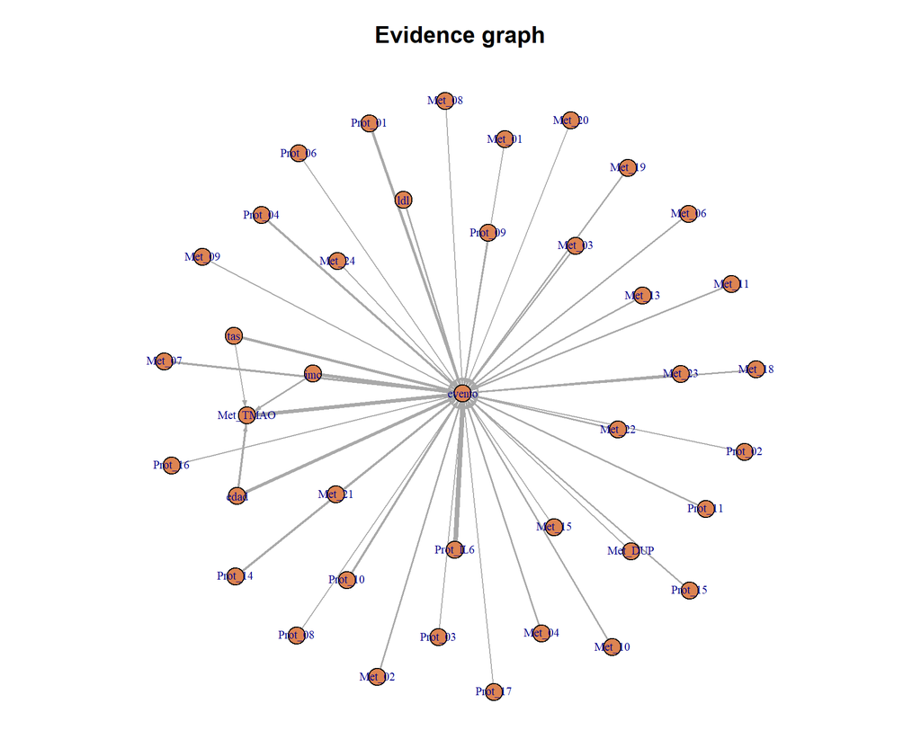

```r
plot(resultado, "network")
```

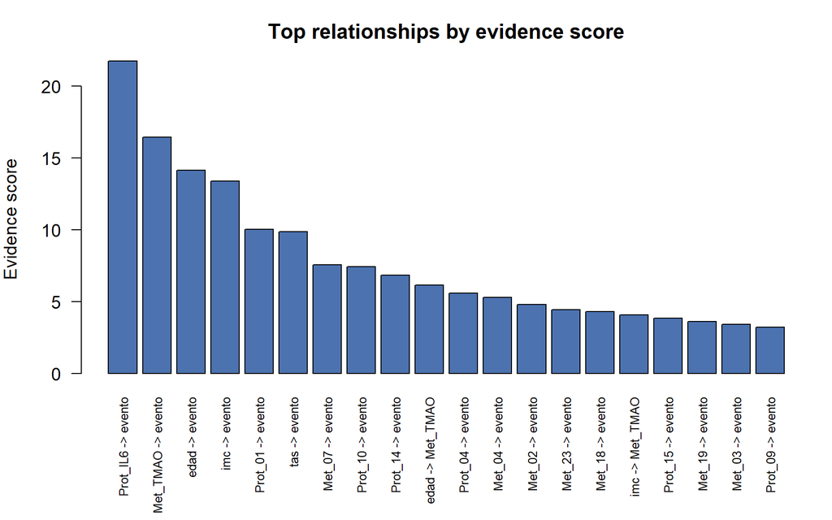

```r
plot(resultado, "evidence_scores")
```

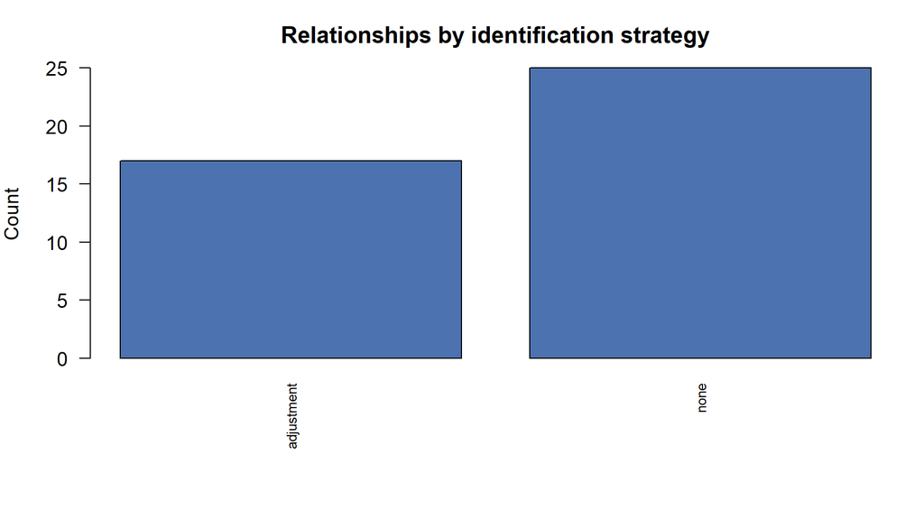

```r
plot(resultado, "identification")
```

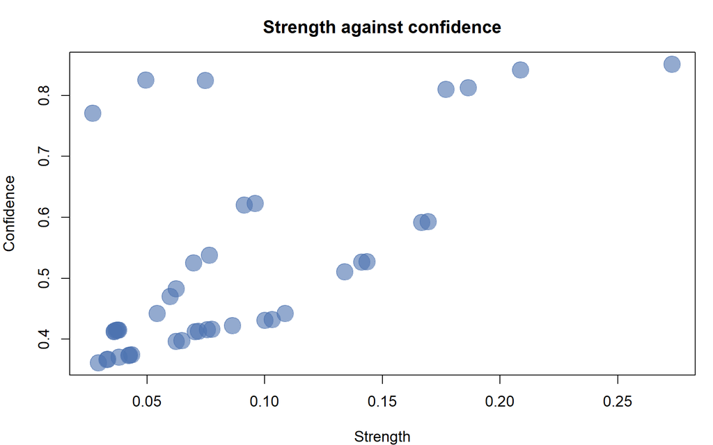

```r
plot(resultado, "score_components")
```

# 7 Leer un hallazgo

`explain()` es la salida que convierte una fila de una tabla en algo que se puede discutir en una reunión: qué se estimó, en qué escala, qué lo apoya, qué lo amenaza y qué habría que medir para zanjarlo.

```r
explain(resultado, "Prot_IL6")
```

```
#>
#> Why does Prot_IL6 appear in this analysis?
#> ============================================================
#>
#> Role: hub, associated with a higher outcome
#>
#> Relationship with evento
#> ----------------------------------------
#>   Direction                Higher Prot_IL6 goes together with higher evento
#>   Evidence score           21.7 / 100
#>   Highest evidence         associational (level 2)
#>   Identification           adjustment
#>   Per the supplied DAG     identified
#>     The adjustment closes every backdoor path from Prot_IL6 to evento
#>     under the DAG supplied.
#>   E-value                  5.62 - explaining this away needs an implausibly strong confounder
#>   Recovered in             100% of resamples
#>   Halved by removing       60 sample(s), 15% of the cohort
#>   Data quality             0.94 (score scaled by this)
#>     10% of this variable was missing and was filled in by the column
#>     median.
#>
#>   What each method found on its own
#>                    method               measured pooled estimate CI low CI high        p   n agrees
#>       logistic regression         log odds ratio   TRUE   1.1256  0.842    1.41 7.95e-15 400   TRUE
#>               elastic net  penalised coefficient  FALSE   0.3495     NA      NA       NA 400   TRUE
#>  random forest importance permutation importance  FALSE   0.0318     NA      NA       NA 400   TRUE
#>
#>   Headline estimate: log odds ratio, pooled from 1 observation(s).
#>   Not combined, being different measurements: penalised coefficient, permutation importance
#>
#>   What those methods are
#>
#>     association
#>       Fits a straight line between the variable and the outcome,
#>       after subtracting the effect of any factors you asked it to
#>       account for.
#>       Limitation: It cannot tell which one came first, and it can
#>       only account for factors that were actually measured.
#>
```

[output cut: 44 more lines]

```
#>     - Any shared cause of the two variables is fully reflected in the
#>       estimate.
#>     - Penalised multivariable fit: every selected feature is
#>       conditioned on the others.
#>     - Selection is not inference; the penalty biases coefficients
#>       towards zero.
#>     - Correlated features compete, so an omitted feature is not
#>       evidence of no effect.
#>     - Permutation importance is a predictive quantity, not an effect
#>       estimate.
#>     - Importance is conditional on the other features present in the
#>       forest.
#>     - Correlated features share importance, which dilutes both.
#>
#> Ranked by 3 method(s), combined ranking 1
```

```r
# el ruido de mayor puntuacion que llego al grafo, elegido de la propia tabla
# para que el documento no dependa de una semilla concreta
ruidosas <- hallazgos$source[grepl("^(Met|Prot)_[0-9]{2}$", hallazgos$source)]
contraste <- ruidosas[1]
contraste
```

```
#> [1] "Prot_01"
```

```r
explain(resultado, contraste)
```

```
#>
#> Why does Prot_01 appear in this analysis?
#> ============================================================
#>
#> Role: hub, associated with a lower outcome
#>
#> Relationship with evento
#> ----------------------------------------
#>   Direction                Higher Prot_01 goes together with lower evento
#>   Evidence score           10.1 / 100
#>   Highest evidence         associational (level 2)
#>   Identification           none
#>   E-value                  1.75 - a modest unmeasured confounder would explain this away
#>   Recovered in             92% of resamples
#>
#>   What each method found on its own
#>               method       measured pooled estimate CI low CI high      p   n agrees
#>  logistic regression log odds ratio   TRUE   -0.204  -0.42  0.0117 0.0638 400   TRUE
#>
#>   Headline estimate: log odds ratio, pooled from 1 observation(s).
#>
#>   What those methods are
#>
#>     association
#>       Fits a straight line between the variable and the outcome,
#>       after subtracting the effect of any factors you asked it to
#>       account for.
#>       Limitation: It cannot tell which one came first, and it can
#>       only account for factors that were actually measured.
#>
#>   Score, opened up
#>                 component     value weight
#>               Effect size 0.1695500   0.34
#>                 Precision 0.5929808   0.33
#>          Method agreement 1.0000000   0.33
#>              Data quality 1.0000000     NA
#>  Spread across the cohort        NA     NA
#>            Evidence level 0.4000000     NA
#>          Temporal support 0.0000000     NA
#>      Direction confidence        NA     NA
#>       Bootstrap stability 0.9200000     NA
#>     Sensitivity (E-value) 0.3507149     NA
#>        Biological support        NA     NA
#>                                                              note
#>                                     how large the relationship is
#>                                      how tightly it was estimated
#>                    weighted by the epistemic level of each method
#>                                          nothing here was imputed
#>                                                       not checked
#>                              highest level reached: associational
#>                                              no measurement order
#>                                                          untested
#>                                    recovered in 0.92 of resamples
#>  E = 1.75, a modest unmeasured confounder would explain this away
#>                        reported alongside, never inside the score
#>
#>   What would have to be true
#>     - No adjustment was made; the estimate is a marginal association.
#>     - Any shared cause of the two variables is fully reflected in the
#>       estimate.
#>
#> Ranked by 1 method(s), combined ranking 0.878
```

# 8 ¿Recuperó la estructura que planté?

Esta es la pregunta que un documento de ejemplo debe contestar, porque es la única forma de saber si lo anterior sirve para algo.

```r
verdad <- data.frame(
  from = c("edad", "Met_TMAO", "Prot_IL6", "edad", "ldl", "imc"),
  to   = c("Met_TMAO", "Prot_IL6", "evento", "evento", "evento", "Met_TMAO"),
  stringsAsFactors = FALSE)

encontrada <- function(a, b) {
  hit <- hallazgos[(hallazgos$source == a & hallazgos$target == b) |
                   (hallazgos$source == b & hallazgos$target == a), ]
  if (!nrow(hit)) return(c(NA_real_, NA_integer_))
  c(hit$evidence_score[1], hit$n_methods[1])
}

marcador <- cbind(verdad, t(mapply(encontrada, verdad$from, verdad$to)))
names(marcador)[3:4] <- c("evidencia", "n_metodos")
marcador$recuperada <- !is.na(marcador$evidencia)
marcador
```

|  | from | to | evidencia | n_metodos | recuperada |
| --- | --- | --- | --- | --- | --- |
| edad | edad | Met_TMAO | 6.17 | 1 | TRUE |
| Met_TMAO | Met_TMAO | Prot_IL6 | NA | NA | FALSE |
| Prot_IL6 | Prot_IL6 | evento | 21.73 | 3 | TRUE |
| edad.1 | edad | evento | 14.16 | 2 | TRUE |
| ldl | ldl | evento | 3.14 | 1 | TRUE |
| imc | imc | Met_TMAO | 4.09 | 1 | TRUE |

```r
# ¿y el ruido? los controles negativos y el resto de variables inventadas
ruido <- hallazgos[grepl("^Met_[0-9]|^Prot_[0-9]", hallazgos$source), ]

data.frame(
  aristas_totales          = nrow(hallazgos),
  del_ruido                = nrow(ruido),
  del_ruido_con_fdr_005    = sum(ruido$fdr < 0.05, na.rm = TRUE),
  controles_negativos_fdr  = sum(hallazgos$fdr[hallazgos$source %in%
                                  c("Met_20", "Prot_15")] < 0.05, na.rm = TRUE),
  con_acuerdo_de_2_o_mas   = sum(hallazgos$n_methods > 1)
)
```

| aristas_totales | del_ruido | del_ruido_con_fdr_005 | controles_negativos_fdr | con_acuerdo_de_2_o_mas |
| --- | --- | --- | --- | --- |
| 42 | 32 | 0 | 0 | 17 |

Conviene leer ese recuento sin adornarlo, así que lo escribo también en una frase calculada, no redactada:

```r
top4   <- head(hallazgos$source, 4)
plantadas <- c("Prot_IL6", "Met_TMAO", "edad", "imc", "ldl")
data.frame(
  top4_de_la_via_plantada  = sum(top4 %in% plantadas),
  ruido_con_fdr_005        = sum(ruido$fdr < 0.05, na.rm = TRUE),
  ruido_total              = nrow(ruido),
  evidencia_min_plantada   = round(min(hallazgos$evidence_score[
                               hallazgos$source %in% plantadas]), 1),
  evidencia_max_ruido      = round(max(ruido$evidence_score), 1),
  metodos_max_plantada     = max(hallazgos$n_methods[
                               hallazgos$source %in% plantadas]),
  metodos_max_ruido        = max(ruido$n_methods)
)
```

| top4_de_la_via_plantada | ruido_con_fdr_005 | ruido_total | evidencia_min_plantada | evidencia_max_ruido | metodos_max_plantada | metodos_max_ruido |
| --- | --- | --- | --- | --- | --- | --- |
| 4 | 0 | 32 | 3.1 | 10.1 | 3 | 2 |

Merece la pena leer ese cuadro despacio, porque no dice lo que uno querría que dijese. **La cabeza del ranking está limpia y la cola no.** Las cuatro relaciones de mayor evidencia son las plantadas, y ninguna de las 32 de ruido cruza FDR < 0.05. Pero la más débil de las plantadas —`ldl → evento`, que existe por construcción— puntúa **por debajo** de la arista de ruido con mejor puntuación, y hay ruido visto por dos métodos.

Ésa es la lectura correcta: la puntuación de evidencia ordena bien lo fuerte y no distingue lo débil del azar. Un efecto real pero pequeño se hunde entre el ruido, y ninguna cantidad de métodos lo arregla —es una limitación del tamaño de muestra, no del procedimiento—. Por eso el paquete imprime la escala de identificación, el número de métodos y el `e_value` en lugar de un único número: para que la decisión de a qué arista hacer caso la tome quien conoce la biología, no un umbral.

La arista `Met_TMAO → Prot_IL6` no aparece: el motor prioriza las relaciones con el desenlace, así que una relación entre dos variables intermedias solo emerge a través de las vías.

## 8.1 Las vías

```r
head(resultado$tables$paths, 6)
```

| path | origin | length | mediators | weakest_link | mean_evidence |
| --- | --- | --- | --- | --- | --- |
| edad -> Met_TMAO -> evento | edad | 2 | Met_TMAO | 6.17 | 11.30 |
| imc -> Met_TMAO -> evento | imc | 2 | Met_TMAO | 4.09 | 10.26 |
| tas -> Met_TMAO -> evento | tas | 2 | Met_TMAO | 2.09 | 9.26 |

Ahí está la cadena `edad → Met_TMAO → evento`, con el eslabón más débil identificado —que es lo que limita la credibilidad de toda la vía, no su promedio.

# 9 ¿Aguanta el resultado?

## 9.1 A través de las rutas de preprocesado

La pregunta incómoda: ¿el hallazgo depende de las decisiones que tomé al imputar, transformar y escalar? `sensitivity()` reajusta el efecto a lo largo de todas las rutas defendibles.

```r
sensibilidad <- sensitivity(resultado)
```

```
#> Refitting Prot_IL6 -> evento under 12 preprocessing path(s)...
```

```r
sensibilidad
```

```
#>
#> CMOSensitivity
#> ==============
#>
#>   Prot_IL6  ->  evento
#>
#> The path taken:              1.1301 per SD  (1.1256 per unit, as reported)
#> Paths that ran:              12 of 12 attempted
#>
#> Across paths, per SD:        1.0999 to 1.2938
#> Median:                      1.1301
#> Agree on direction:          100%
#> Reach p < 0.05:              100%
#>
#>   This relationship holds down every reasonable path.
#>
#> Every path
#> ------------------------------------------------------------------
#>   median    rank        z-score     1.0999  p = 5.9e-15
#>   mean      rank        z-score     1.0999  p = 5.9e-15
#>   knn       rank        z-score     1.0999  p = 5.9e-15
#>   median    identity    z-score     1.1256  p = 8e-15      <- reported
#>   mean      identity    z-score     1.1256  p = 8e-15
#>   knn       identity    z-score     1.1256  p = 8e-15
#>   median    yeojohnson  z-score     1.1347  p = 8.7e-15
#>   mean      yeojohnson  z-score     1.1347  p = 8.7e-15
#>   knn       yeojohnson  z-score     1.1347  p = 8.7e-15
#>   median    log         z-score     1.2938  p = 4.7e-14
#>   mean      log         z-score     1.2938  p = 4.7e-14
#>   knn       log         z-score     1.2938  p = 4.7e-14
#>
#> How to read this
#> ------------------------------------------------------------------
#>   Only the choices this package makes on your behalf are varied:
#>   imputation, transformation and scaling. Sample filters are held
#>   fixed, because changing who is in the study changes the
#>   question rather than the answer.
#>   The number to read is the share of paths agreeing on the
#>   direction, not the median. A median across a set of paths that
#>   disagree is a summary of the disagreement.
#>   Stability here is not evidence that the relationship is real. A
#>   chance correlation in this sample is not created or destroyed
#>   by how the data was transformed, only re-expressed, so noise
#>   passes this check comfortably. It measures dependence on the
#>   analyst. Null calibration and replication in another cohort are
#>   what address the other question.
```

```r
head(as.data.frame(sensibilidad), 8)
```

| path | imputation | transformation | scaling | is_original | estimate | raw_estimate | se | p_value | n | source | target |
| --- | --- | --- | --- | --- | --- | --- | --- | --- | --- | --- | --- |
| 10 | median | rank | z-score | FALSE | 1.099921 | 1.099921 | 0.1408963 | 0 | 400 | Prot_IL6 | evento |
| 11 | mean | rank | z-score | FALSE | 1.099921 | 1.099921 | 0.1408963 | 0 | 400 | Prot_IL6 | evento |
| 12 | knn | rank | z-score | FALSE | 1.099921 | 1.099921 | 0.1408963 | 0 | 400 | Prot_IL6 | evento |
| 1 | median | identity | z-score | TRUE | 1.125628 | 1.125628 | 0.1448997 | 0 | 400 | Prot_IL6 | evento |
| 2 | mean | identity | z-score | FALSE | 1.125628 | 1.125628 | 0.1448997 | 0 | 400 | Prot_IL6 | evento |
| 3 | knn | identity | z-score | FALSE | 1.125628 | 1.125628 | 0.1448997 | 0 | 400 | Prot_IL6 | evento |
| 7 | median | yeojohnson | z-score | FALSE | 1.134662 | 1.134662 | 0.1462838 | 0 | 400 | Prot_IL6 | evento |
| 8 | mean | yeojohnson | z-score | FALSE | 1.134662 | 1.134662 | 0.1462838 | 0 | 400 | Prot_IL6 | evento |

`CMOSensitivity` no guarda figuras, pero la tabla las permite: lo que importa es si la nube de estimadores cruza el nulo.

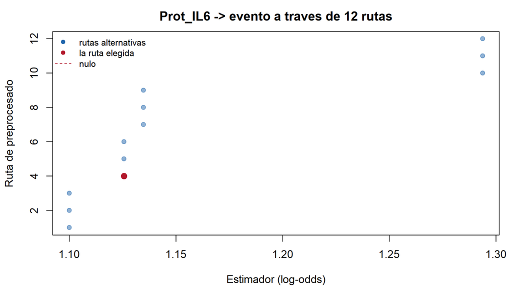

```r
sv <- as.data.frame(sensibilidad)
op <- par(mar = c(4.2, 4.2, 2.5, 1))
plot(sv$estimate, seq_len(nrow(sv)), pch = 19, col = "#2166AC80",
     xlab = "Estimador (log-odds)", ylab = "Ruta de preprocesado",
     main = sprintf("%s -> %s a traves de %d rutas",
                    sv$source[1], sv$target[1], nrow(sv)))
abline(v = 0, lty = 2, col = "#B2182B")
points(sv$estimate[sv$is_original], which(sv$is_original), pch = 19,
       col = "#B2182B", cex = 1.3)
legend("topleft", c("rutas alternativas", "la ruta elegida", "nulo"),
       col = c("#2166AC", "#B2182B", "#B2182B"), pch = c(19, 19, NA),
       lty = c(NA, NA, 2), bty = "n", cex = 0.85)
```

```r
par(op)
```

## 9.2 Frente a un confusor no medido

El `e_value` de la tabla de hallazgos contesta esto directamente: cuán fuerte tendría que ser un confusor no medido para borrar el efecto.

```r
head(hallazgos[, c("source", "target", "estimate", "e_value",
                   "identification", "level_label")], 6)
```

| source | target | estimate | e_value | identification | level_label |
| --- | --- | --- | --- | --- | --- |
| Prot_IL6 | evento | 1.1256276 | 5.615 | adjustment | associational |
| Met_TMAO | evento | 0.8978358 | 4.344 | none | associational |
| edad | evento | 0.5849454 | 2.989 | none | associational |
| imc | evento | 0.5416739 | 2.830 | none | associational |
| Prot_01 | evento | -0.2041664 | 1.754 | none | associational |
| tas | evento | 0.2001320 | 1.742 | none | associational |

## 9.3 ¿Un número describe a todo el mundo?

```r
if (!is.null(resultado$tables$heterogeneity) &&
    NROW(resultado$tables$heterogeneity) > 0) {
  head(resultado$tables$heterogeneity, 6)
} else {
  "Sin resultados de heterogeneidad para esta configuración."
}
```

```
#> [1] "Sin resultados de heterogeneidad para esta configuración."
```

# 10 ¿Qué implicaría cambiar algo?

```r
contrafactual <- counterfactual(resultado, modifiable = c("clinica", "Met_TMAO"))
contrafactual
```

```
#>
#> What the results imply about changing these variables
#> ====================================================================
#>
#> Outcome  : evento (binary)
#> Design   : cross-sectional
#> Change   : increase of one standard deviation, from the median
#> Baseline : 29.2% of people had the event
#>
#>   An increase of 0.9744 in Met_TMAO from 0.07577 is associated with
#>   a 90.9% higher risk of the event.
#>     evidence score 16/100, none
#>     This is an unadjusted association. It is not a prediction of
#>     what would happen if the variable were changed.
#>
#>   An increase of 8.839 in edad from 65 is associated with a 45.6%
#>   higher risk of the event.
#>     evidence score 14/100, none
#>     This is an unadjusted association. It is not a prediction of
#>     what would happen if the variable were changed.
#>
#>   An increase of 3.955 in imc from 27.6 is associated with a 42.0%
#>   higher risk of the event.
#>     evidence score 13/100, none
#>     This is an unadjusted association. It is not a prediction of
#>     what would happen if the variable were changed.
#>
#>   An increase of 16.05 in tas from 135.5 is associated with a 14.7%
#>   higher risk of the event.
#>     evidence score 10/100, none
#>     This is an unadjusted association. It is not a prediction of
#>     what would happen if the variable were changed.
#>
#>   An increase of 27.39 in ldl from 113 is associated with a 5.9%
#>   higher risk of the event.
#>     evidence score 3/100, none
#>     This is an unadjusted association. It is not a prediction of
#>     what would happen if the variable were changed.
#>
#> --------------------------------------------------------------------
#>  variable     from       to    measure  value percent_change identification
#>  Met_TMAO   0.0758   1.0501 odds ratio 3.0596          90.93           none
#>      edad  65.0000  73.8393 odds ratio 1.7949          45.63           none
#>       imc  27.6000  31.5548 odds ratio 1.7189          42.02           none
#>       tas 135.5000 151.5486 odds ratio 1.2216          14.72           none
#>       ldl 113.0000 140.3894 odds ratio 1.0854           5.89           none
```

```r
as.data.frame(contrafactual)
```

| variable | block | from | to | change | measure | value | ci_lower | ci_upper | percent_change | method | identification | evidence_score |
| --- | --- | --- | --- | --- | --- | --- | --- | --- | --- | --- | --- | --- |
| Met_TMAO | metabolomica | 0.0758 | 1.0501 | 0.9744 | odds ratio | 3.0596 | 2.2234 | 4.2102 | 90.93 | logistic regression | none | 16.4 |
| edad | clinica | 65.0000 | 73.8393 | 8.8393 | odds ratio | 1.7949 | 1.4100 | 2.2848 | 45.63 | logistic regression | none | 14.2 |
| imc | clinica | 27.6000 | 31.5548 | 3.9548 | odds ratio | 1.7189 | 1.3644 | 2.1655 | 42.02 | logistic regression | none | 13.4 |
| tas | clinica | 135.5000 | 151.5486 | 16.0486 | odds ratio | 1.2216 | 0.9835 | 1.5173 | 14.72 | logistic regression | none | 9.9 |
| ldl | clinica | 113.0000 | 140.3894 | 27.3894 | odds ratio | 1.0854 | 0.8746 | 1.3470 | 5.89 | logistic regression | none | 3.1 |

Cada fila lleva su etiqueta de identificación: `adjustment` cuando el conjunto de ajuste estaba completo, `none` cuando no. La redacción nunca dice «reduciría» sin que un instrumento lo respalde, porque un contraste implicado por un modelo no es una predicción de lo que haría una intervención.

# 11 El DAG por separado

`check_dag()` contesta la pregunta de identificación sin tocar los datos: con este grafo y este conjunto de ajuste, ¿el efecto es identificable?

```r
if (requireNamespace("dagitty", quietly = TRUE)) {

  # ajustando por los confusores correctos
  print(check_dag(verdad, "Prot_IL6", "evento", adjusted = c("edad", "imc")))

} else {
  "Requiere el paquete dagitty: install.packages(\"dagitty\")"
}
```

```
#>
#> Effect of Prot_IL6 on evento
#> ============================================================
#>
#> Adjusted for : edad, imc
#> Verdict      : IDENTIFIED
#>
#>   The adjustment closes every backdoor path from Prot_IL6
#>   to evento under the DAG supplied.
#>
#> A sufficient adjustment set
#> ------------------------------------------------------------
#>   edad
#>
#>   This holds only if the structure you supplied is correct.
#>   The data cannot confirm it.
```

```r
if (requireNamespace("dagitty", quietly = TRUE)) {

  # ajustando por el mediador: se elimina justamente el efecto que se mide
  print(check_dag(verdad, "edad", "evento",
                  adjusted = c("Met_TMAO", "Prot_IL6")))

}
```

```
#>
#> Effect of edad on evento
#> ============================================================
#>
#> Adjusted for : Met_TMAO, Prot_IL6
#> Verdict      : NOT identified
#>
#>   Conditioning on Met_TMAO, Prot_IL6 is what breaks this:
#>   they should not be in the adjustment set at all.
#>
#> Problems with the adjustment
#> ------------------------------------------------------------
#>   - Conditioned on Met_TMAO, Prot_IL6, which lies on the path
#>     from edad to evento: part of the effect being measured
#>     has been removed.
```

# 12 Afirmar algo que podría ser falso

`hypothesis()` congela una afirmación con su protocolo: qué desenlace, qué ajuste, qué modelo. Eso es lo que se lleva a otra cohorte.

```r
afirmacion <- hypothesis(resultado)
afirmacion
```

```
#>
#> Hypothesis
#> ==========================================================================
#>
#>   Raising Prot_IL6 would raise evento.
#>
#>   This is an effect identified by the causal diagram you supplied.
#>
#>   Effect:                1.1256 (log odds ratio)
#>   95% CI:                [0.8416, 1.4096]
#>   Identification:        adjustment
#>
#>   - Measured confounders were adjusted for; unmeasured ones cannot be.
#>   - That diagram says the adjustment closes every backdoor path. The data
#>     cannot confirm the diagram is right.
#>
#> What supports it
#> --------------------------------------------------------------------------
#>   + 3 independent methods found it, agreeing on the direction: logistic
#>     regression, elastic net, random forest importance.
#>   + It survives correction for the number of relationships tested (FDR
#>     3.9e-13).
#>   + Explaining it away needs a confounder associated with both at 5.6 or
#>     more, which is stronger than most measured risk factors.
#>   + It reappeared in 100% of resamples of this cohort.
#>
#> What threatens it
#> --------------------------------------------------------------------------
#>   - Part of it rests on values that were filled in rather than measured
#>     (quality 0.94).
#>
#> What would settle it
#> --------------------------------------------------------------------------
#>   > Look for a common cause of Prot_IL6 and evento that your diagram does
#>     not have. The diagram is what makes this an effect rather than an
#>     association, and a confounder of at least 5.6 outside it would erase
#>     both.
#>   > Measure Prot_IL6 before evento in the same people. Nothing in this
#>     data establishes which came first, and the reverse direction fits it
#>     equally well.
#>   > Measure Prot_04 in the people whose value was filled in. Part of this
#>     estimate rests on numbers that were reconstructed rather than
#>     observed.
#>
#>   From CausalMultiOmics 0.1.1, 400 sample(s), score 21.7.
```

## 12.1 Replicarla en una cohorte nueva

Lo importante es que la segunda cohorte se pone en la **misma escala** que la primera —con los modelos ya ajustados— en lugar de preprocesarse por su cuenta. Eso es `apply_preprocessing()`.

```r
set.seed(77)
n2  <- 250
id2 <- sprintf("VAL%04d", seq_len(n2))

edad2 <- round(rnorm(n2, 66, 8)); imc2 <- rnorm(n2, 28.5, 4)
tmao2 <- 0.55 * scale(edad2)[, 1] + 0.30 * scale(imc2)[, 1] + rnorm(n2, 0, .75)
il62  <- 0.60 * tmao2 + 0.25 * scale(imc2)[, 1] + rnorm(n2, 0, .75)

cohorte2 <- load_data(
  assays = list(
    clinica = data.frame(edad = edad2, sexo = rbinom(n2, 1, .5),
                         imc = round(imc2, 1),
                         tas = round(rnorm(n2, 138, 16)),
                         ldl = round(rnorm(n2, 115, 28)), row.names = id2),
    metabolomica = as.data.frame(
      cbind(Met_TMAO = tmao2, matrix(rnorm(n2 * 24), n2, 24,
            dimnames = list(NULL, sprintf("Met_%02d", 1:24)))), row.names = id2),
    proteomica = as.data.frame(
      cbind(Prot_IL6 = il62, matrix(rnorm(n2 * 17), n2, 17,
            dimnames = list(NULL, sprintf("Prot_%02d", 1:17)))), row.names = id2)),
  metadata = data.frame(
    sample_id = id2,
    evento = rbinom(n2, 1, plogis(-1.1 + 0.85 * il62 + 0.45 * tmao2 +
                                    0.030 * (edad2 - 64))),
    stringsAsFactors = FALSE))

validacion <- apply_preprocessing(cohorte2, listo)
```

```
#> Replaying 'clinica'...
#> Replaying 'metabolomica'...
#> Replaying 'proteomica'...
```

```r
test_hypothesis(afirmacion, validacion)
```

```
#>
#> Hypothesis
#> ==========================================================================
#>
#>   Raising Prot_IL6 would raise evento.
#>
#>   This is an effect identified by the causal diagram you supplied.
#>
#>   Effect:                1.1256 (log odds ratio)
#>   95% CI:                [0.8416, 1.4096]
#>   Identification:        adjustment
#>
#>   - Measured confounders were adjusted for; unmeasured ones cannot be.
#>   - That diagram says the adjustment closes every backdoor path. The data
#>     cannot confirm the diagram is right.
#>
#> What supports it
#> --------------------------------------------------------------------------
#>   + 3 independent methods found it, agreeing on the direction: logistic
#>     regression, elastic net, random forest importance.
#>   + It survives correction for the number of relationships tested (FDR
#>     3.9e-13).
#>   + Explaining it away needs a confounder associated with both at 5.6 or
#>     more, which is stronger than most measured risk factors.
#>   + It reappeared in 100% of resamples of this cohort.
#>
#> What threatens it
#> --------------------------------------------------------------------------
#>   - Part of it rests on values that were filled in rather than measured
#>     (quality 0.94).
#>
#> What would settle it
#> --------------------------------------------------------------------------
#>   > Look for a common cause of Prot_IL6 and evento that your diagram does
#>     not have. The diagram is what makes this an effect rather than an
#>     association, and a confounder of at least 5.6 outside it would erase
#>     both.
#>   > Measure Prot_IL6 before evento in the same people. Nothing in this
#>     data establishes which came first, and the reverse direction fits it
#>     equally well.
#>   > Measure Prot_04 in the people whose value was filled in. Part of this
#>     estimate rests on numbers that were reconstructed rather than
#>     observed.
#>
#> Tested on another cohort
#> --------------------------------------------------------------------------
#>   Verdict:               REPLICATED
#>   There:                 1.4889 [1.0700, 1.9078], n = 250, p = 3.2e-12
#>   Here:                  1.1256
#>   Size:                  132% of the original
#>   ! Adjusted for 0 of 48 covariates: Met_TMAO, edad, sexo, imc, tas, ldl,
#>     Met_01, Met_02, Met_03, Met_04, Met_05, Met_06, Met_07, Met_08,
#>     Met_09, Met_10, Met_11, Met_12, Met_13, Met_14, Met_15, Met_16,
#>     Met_17, Met_18, Met_19, Met_20, Met_21, Met_22, Met_23, Met_24,
#>     Met_DUP, Prot_01, Prot_02, Prot_03, Prot_04, Prot_05, Prot_06,
#>     Prot_07, Prot_08, Prot_09, Prot_10, Prot_11, Prot_12, Prot_13,
#>     Prot_14, Prot_15, Prot_16, Prot_17 were not available, so this is not
#>     the same model.
#>   ! A replication tests the claim, not the analysis that produced it.
#>
#>   From CausalMultiOmics 0.1.1, 400 sample(s), score 21.7.
```

La replicación no es que los valores p coincidan. Una afirmación replica cuando el nuevo estimador apunta al mismo sitio y es de tamaño comparable; el fallo más común es una dirección que se mantiene con un efecto cinco veces menor, que una prueba de significación llamaría éxito.

# 13 Dos configuraciones del mismo análisis

`compare_results()` compara dos análisis y, antes de comparar nada, comprueba que preguntan lo mismo. Aquí el contraste útil es el mismo desenlace con y sin declarar el DAG.

```r
sin_dag <- analyze(listo, outcome = "evento", effort = "fast",
                   plots = FALSE, quiet = TRUE,
                   control = analysis_control(
                     methods = c("association", "conditional"), seed = 2024))

con_dag <- analyze(listo, outcome = "evento", effort = "fast",
                   plots = FALSE, quiet = TRUE,
                   assume = analysis_assumptions(dag = verdad),
                   control = analysis_control(
                     methods = c("association", "conditional"), seed = 2024))

compare_results(sin_dag, con_dag, names = c("sin DAG", "con DAG"))
```

```
#>
#> CMOComparison
#> =============
#>
#>   sin DAG  vs  con DAG
#>
#>   Same outcome, same design, same adjustment: comparable.
#>
#> Found in the sin DAG:        44
#> Found in the con DAG:        44
#> In both:                     44
#> Overlap (Jaccard):           1.00
#>
#> How to read this
#> ------------------------------------------------------------------
#>   44 relationship(s) in both, 0 only in the sin DAG, 0 only in
#>   the con DAG.
#>   A relationship missing from one of two analyses has not been
#>   refuted by it. It may simply not have cleared the threshold
#>   there, and the two lists are not a test of each other.
#>
#>   Nothing here is pooled. Comparing two estimates does not average
#>   them, and averaging needs them on one scale with one adjustment.
```

Y el caso que conviene ver aunque no sea el uso previsto: comparar dos desenlaces distintos. El paquete se niega a tratarlo como una comparación y explica por qué, que es exactamente lo que debería hacer.

```r
otro <- analyze(listo, outcome = "hdl", effort = "fast", plots = FALSE,
                quiet = TRUE,
                control = analysis_control(methods = "association", seed = 2024))

compare_results(resultado, otro, names = c("evento", "hdl"))
```

```
#>
#> CMOComparison
#> =============
#>
#>   evento  vs  hdl
#>
#> These two analyses did not ask the same question
#> ------------------------------------------------------------------
#>   ! Different outcomes: 'evento' and 'hdl'. These are answers to
#>     two questions.
#>   ! Different kinds of outcome: binary and continuous, so the
#>     estimates are not on the same scale.
#>   ! Different adjustment: edad, imc, ldl, mediator path, Met_01,
#>     Met_02, Met_03, Met_04, Met_05, Met_06, Met_07, Met_08,
#>     Met_09, Met_10, Met_11, Met_12, Met_13, Met_14, Met_15,
#>     Met_16, Met_17, Met_18, Met_19, Met_20, Met_21, Met_22,
#>     Met_23, Met_24, Met_DUP, Met_TMAO, Prot_01, Prot_02, Prot_03,
#>     Prot_04, Prot_05, Prot_06, Prot_07, Prot_08, Prot_09,
#>     Prot_10, Prot_11, Prot_12, Prot_13, Prot_14, Prot_15,
#>     Prot_16, Prot_17, Prot_IL6, sexo, tas against nothing. An
#>     estimate adjusted for different things is a different
#>     estimate.
#>
#> Found in the evento:         42
#> Found in the hdl:            49
#> In both:                     0
#> Overlap (Jaccard):           0.00
#>
#> Only in the evento
#> ------------------------------------------------------------------
#>   Prot_IL6 -> evento
#>   Met_TMAO -> evento
#>   edad -> evento
#>   imc -> evento
#>   Prot_01 -> evento
#>   tas -> evento
#>   Met_07 -> evento
#>   Prot_10 -> evento
#>   Prot_14 -> evento
#>   edad -> Met_TMAO
```

[output cut: 17 more lines]

```
#>   Nothing in the first analysis rules these out either.
#>
#> How to read this
#> ------------------------------------------------------------------
#>   The two analyses did not ask the same question; see the
#>   warnings above. Everything below compares numbers that may not
#>   be on the same scale.
#>   0 relationship(s) in both, 42 only in the evento, 49 only in
#>   the hdl.
#>   A relationship missing from one of two analyses has not been
#>   refuted by it. It may simply not have cleared the threshold
#>   there, and the two lists are not a test of each other.
#>
#>   Nothing here is pooled. Comparing two estimates does not average
#>   them, and averaging needs them on one scale with one adjustment.
```

# 14 Anotación biológica externa

Queda fuera de `analyze()` a propósito: las bases de pathways se consultan por red, y meterlas dentro haría que el análisis no fuese reproducible. Como paso aparte, la anotación es un acto explícito y fechado.

```r
soporte <- data.frame(
  source   = c("Prot_IL6", "Met_TMAO"),
  target   = c("evento", "evento"),
  support  = c(0.92, 0.78),
  database = "exportación local de ejemplo",
  stringsAsFactors = FALSE)

anotado <- annotate_evidence(resultado, soporte)
head(as.data.frame(anotado, all = TRUE)[, c("source", "target",
     grep("support|database|annotat", names(as.data.frame(anotado, all = TRUE)),
          value = TRUE))], 4)
```

| source | target |
| --- | --- |
| Prot_IL6 | evento |
| Met_TMAO | evento |
| edad | evento |
| imc | evento |

# 15 Entregables

## 15.1 Informe HTML

```r
destino <- file.path(tempdir(), "informe-cardio.html")
report(resultado, file = destino)
```

```
#> Building HTML report...
#> Report saved to: C:\Users\USER\AppData\Local\Packages\operon.kernel.3924db848884.fb9047c40680f3c25\AC\Temp\RtmpUR7Fvw/informe-cardio.html
#> Size: 704.0 KB
```

```r
c(existe = file.exists(destino), KB = round(file.size(destino) / 1024))
```

```
#> existe     KB
#>      1    705
```

## 15.2 El grafo para Cytoscape o igraph

```r
g <- file.path(tempdir(), "grafo.graphml")
export_graph(resultado, g, format = "graphml")

c(KB = round(file.size(g) / 1024))
```

```
#> KB
#> 39
```

# 16 Qué llevan dentro los objetos

Importa por dos razones: el tamaño y, sobre todo, porque son **datos individuales de pacientes**. Quien comparta un `.rds` de estos debería saber qué va dentro.

```r
objetos <- list(datos = datos, auditoria = auditoria, listo = listo,
                resultado = resultado, sensibilidad = sensibilidad)

data.frame(
  objeto = names(objetos),
  clase  = sapply(objetos, function(x) class(x)[1]),
  MB     = round(sapply(objetos, function(x)
             as.numeric(object.size(x)) / 1024^2), 1),
  cohorte_dentro = sapply(objetos, function(x)
    !is.null(x$data$assays) || !is.null(x$assays) || !is.null(x$input$assays)),
  row.names = NULL
)
```

| objeto | clase | MB | cohorte_dentro |
| --- | --- | --- | --- |
| datos | MultiOmicsData | 0.3 | TRUE |
| auditoria | CMOValidation | 8.0 | FALSE |
| listo | PreprocessingResult | 5.3 | TRUE |
| resultado | CMOResult | 9.7 | FALSE |
| sensibilidad | CMOSensitivity | 0.0 | FALSE |

Tres cosas concretas, por si hace falta decidir qué se comparte:

- `auditoria` es casi todo figuras grabadas: `check_data(plots = FALSE)` lo deja en una fracción sin cambiar ningún hallazgo.
- `listo` guarda **dos copias completas** de la cohorte, `$input$assays` y `$data$assays`. La segunda hace falta para que `apply_preprocessing()` pueda repetir los modelos en una cohorte nueva.
- `resultado` guarda `$outcome$values`, el desenlace sujeto a sujeto.

# 17 Reproducibilidad

```r
c(semilla_control = control$seed,
  version_paquete = as.character(utils::packageVersion("CausalMultiOmics")))
```

```
#> semilla_control version_paquete
#>          "2024"         "0.1.1"
```

# 18 Resumen del recorrido

Funciones públicas ejercitadas en este documento:

| Etapa | Funciones |
| --- | --- |
| Preparación | `cmo_setup()` |
| Datos | `load_data()`, `print()`, `summary()` |
| Auditoría | `check_data()`, `as.data.frame()`, `cmo_plots()`, `plot()` |
| Preprocesado | `preprocess()`, `apply_preprocessing()`, `as.data.frame()`, `plot()` |
| Supuestos | `analysis_assumptions()`, `analysis_control()` |
| Análisis | `analyze()`, `as.data.frame()`, `outcome_name()`, `plot()` |
| Lectura | `explain()` |
| Robustez | `sensitivity()`, `check_dag()` |
| Acción | `counterfactual()` |
| Afirmación | `hypothesis()`, `test_hypothesis()` |
| Comparación | `compare_results()` |
| Anotación | `annotate_evidence()` |
| Salida | `report()`, `export_graph()` |